# Practical Machine Learning Course Project

Avinash Singh Pundhir

December 21, 2015

Human Activity Recognition (HAR) is a new key field of study that is emerging as a key research area to develop context aware systems. There are many potential applications of HAR. Some of those are following:

- Elderly monitoring
- Life log systems for monitoring energy expenditure and for supporting weight-loss programs
- Digital assistants for weight lifting exercises

Weight Lifting Exercises Dataset:

Weight Lifting Exercises dataset is to investigate “how (well)” an activity was performed by the wearer. Six young health participants were asked to perform one set of 10 repetitions of the Unilateral Dumbbell Biceps Curl in five different fashions: exactly according to the specification (Class A), throwing the elbows to the front (Class B), lifting the dumbbell only halfway (Class C), lowering the dumbbell only halfway (Class D) and throwing the hips to the front (Class E).

Class A corresponds to the specified execution of the exercise, while the other 4 classes correspond to common mistakes.

Read more: http://groupware.les.inf.puc-rio.br/har#ixzz3v3mADg7n

```r
library(caret)
library(dplyr)
```

### Getting and Cleaning Data

```r
setwd("C:\\Users\\Avinash\\Desktop\\R Files\\Coursera\\Machine Learning")

hardata <- read.csv("pml-training.csv")

#Cleaning Data
hardata <- select(hardata,
                  -X,
                  -user_name,
                  -raw_timestamp_part_1,
                  -raw_timestamp_part_2,
                  -cvtd_timestamp,
                  -new_window,
                  -num_window)
#Extracting belt, arm, dumbell, forearm related variables only
hardata <- hardata[, grepl("gyros|accel|magnet|classe", names(hardata))]
hardata <- select(hardata, -starts_with("var"))

dim(hardata)
```

```
## [1] 19622    41
```

### Creating Training and Test Sets

```r
set.seed(1456)
intrain <- createDataPartition(y = hardata$classe,
                               p = 0.6,
                               list = FALSE)
traincomplete <- hardata[intrain,]
testing <- hardata[-intrain,]
dim(traincomplete)
```

```
## [1] 11776    41
```

```r
dim(testing)
```

```
## [1] 7846   41
```

### Feature Plots for Exploratory Analysis

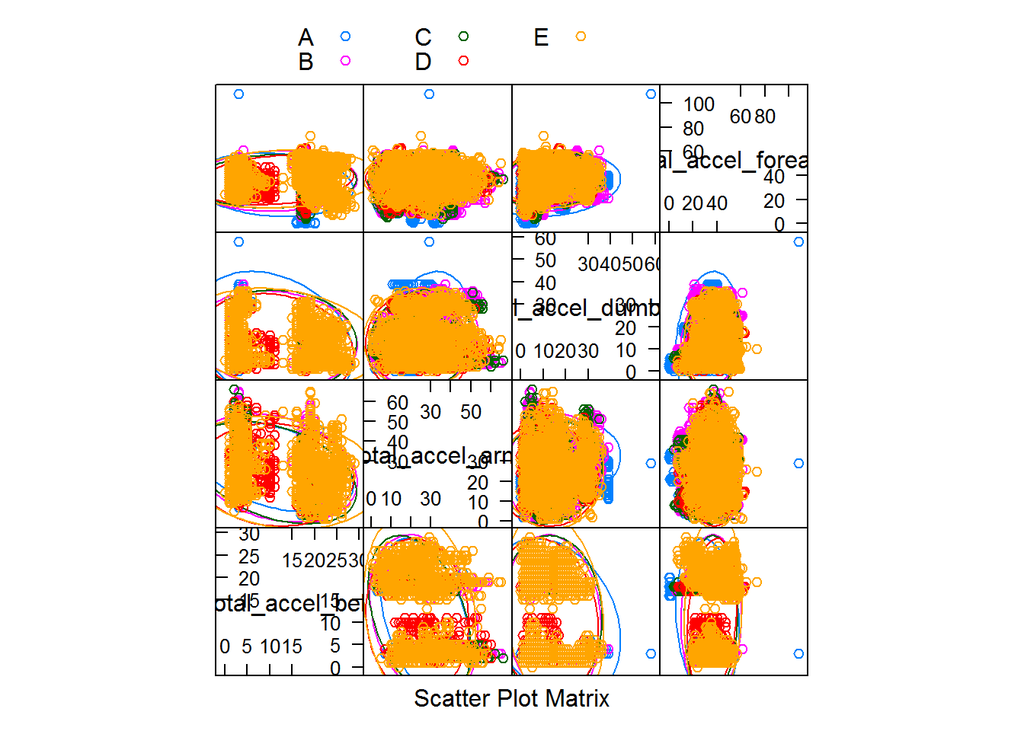

```r
featurePlot(x = traincomplete[, c("total_accel_belt",
                                  "total_accel_arm",
                                  "total_accel_dumbbell",
                                  "total_accel_forearm")],
            y = traincomplete$classe,
            plot = "ellipse",
            auto.key = list(columns = 4))
```

### Fitting Random Forest Classification Model

```r
#Adding Repeated K Fold Cross Validation

fitCOntrol <- trainControl(method = "repeatedcv",
                           number = 10,
                           repeats = 3)

rffit <- train(classe ~ .,
               data = traincomplete,
               method = "rf",
               trControl = fitCOntrol)

print(rffit, digits = 3)
```

```
## Random Forest
##
## 11776 samples
##    40 predictor
##     5 classes: 'A', 'B', 'C', 'D', 'E'
##
## No pre-processing
## Resampling: Cross-Validated (10 fold, repeated 3 times)
## Summary of sample sizes: 10600, 10598, 10600, 10598, 10598, 10599, ...
## Resampling results across tuning parameters:
##
##   mtry  Accuracy  Kappa  Accuracy SD  Kappa SD
##    2    0.982     0.977  0.00332      0.00421
##   21    0.979     0.973  0.00392      0.00497
##   40    0.973     0.966  0.00346      0.00438
##
## Accuracy was used to select the optimal model using  the largest value.
## The final value used for the model was mtry = 2.
```

```r
print(rffit$finalModel)
```

```
##
## Call:
##  randomForest(x = x, y = y, mtry = param$mtry)
##                Type of random forest: classification
##                      Number of trees: 500
## No. of variables tried at each split: 2
##
##         OOB estimate of  error rate: 1.68%
## Confusion matrix:
##      A    B    C    D    E class.error
## A 3333    6    4    4    1 0.004480287
## B   40 2215   22    1    1 0.028082492
## C    0   29 2024    0    1 0.014605648
## D    1    0   72 1851    6 0.040932642
## E    1    1    2    6 2155 0.004618938
```

```r
pred1 <- predict(rffit, testing)

confusionMatrix(testing$classe, pred1)
```

```
## Confusion Matrix and Statistics
##
##           Reference
## Prediction    A    B    C    D    E
##          A 2217    5    2    8    0
##          B   26 1471   21    0    0
##          C    0   25 1343    0    0
##          D    2    0   53 1227    4
##          E    0    1    0    1 1440
##
## Overall Statistics
##
##                Accuracy : 0.9811
##                  95% CI : (0.9779, 0.984)
##     No Information Rate : 0.2861
##     P-Value [Acc > NIR] : < 2.2e-16
##
##                   Kappa : 0.9761
##  Mcnemar's Test P-Value : NA
##
## Statistics by Class:
##
##                      Class: A Class: B Class: C Class: D Class: E
## Sensitivity            0.9875   0.9794   0.9464   0.9927   0.9972
## Specificity            0.9973   0.9926   0.9961   0.9911   0.9997
## Pos Pred Value         0.9933   0.9690   0.9817   0.9541   0.9986
## Neg Pred Value         0.9950   0.9951   0.9883   0.9986   0.9994
## Prevalence             0.2861   0.1914   0.1809   0.1575   0.1840
## Detection Rate         0.2826   0.1875   0.1712   0.1564   0.1835
## Detection Prevalence   0.2845   0.1935   0.1744   0.1639   0.1838
## Balanced Accuracy      0.9924   0.9860   0.9713   0.9919   0.9985
```

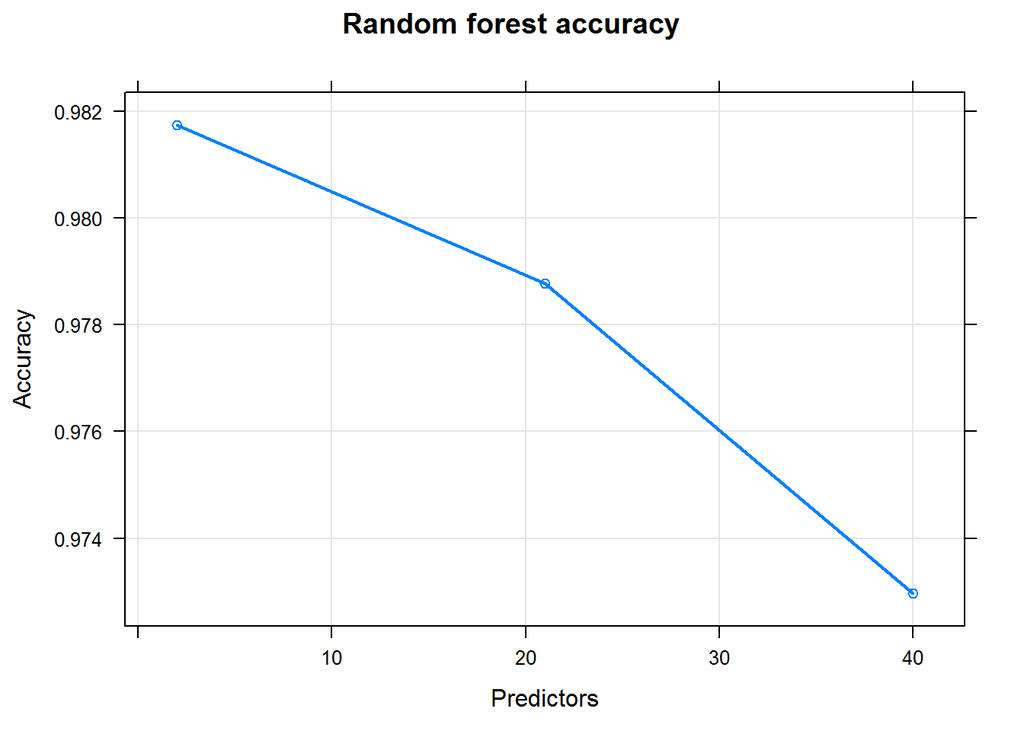

```r
plot(rffit,
     log = "y",
     lwd = 2,
     main = "Random forest accuracy",
     xlab = "Predictors",
     ylab = "Accuracy")
```

- Here we have used repeated K fold cross validation approach for cross validation. Where we have taken K as 10. As larger K would give us less bias and more variance. While using smaller K i.e. in our case we will get more bias and less variance.

### Out of Sample Error

```r
oosaccuracy <- sum(pred1 == testing$classe)/length(pred1)
oose <- round((1 - oosaccuracy)*100,3)
```

- Out of Sample error estimation is 1.886

### Prediction for 20 Test Cases

```r
test <- read.csv("pml-testing.csv")
test <- rename(test, classe = problem_id)
test <- select(test,
                  -X,
                  -user_name,
                  -raw_timestamp_part_1,
                  -raw_timestamp_part_2,
                  -cvtd_timestamp,
                  -new_window,
                  -num_window)
#Extracting belt, arm, dumbell, forearm related variables only
test <- test[, grepl("gyros|accel|magnet|classe", names(test))]
test <- select(test, -starts_with("var"))
pred2 <- predict(rffit, test)
pred2
```

```
##  [1] B A C A A E D B A A B C B A E E A B B B
## Levels: A B C D E
```